# Introduction to R and Data Analysis

From your first line of code to machine learning, with penguins 🐧

Jean Golding Institute

## Today’s mission

344 penguins.  
One day.  
Let’s find out what makes them different.

## Meet the penguins

Palmer Archipelago, Antarctica, 2007–2009

- Adelie
- Chinstrap
- Gentoo

Bill, flipper, body mass, sex, island, year

## Meet the penguins

Palmer Archipelago, Antarctica, 2007–2009

- Adelie
- Chinstrap
- Gentoo

Bill, flipper, body mass, sex, island, year

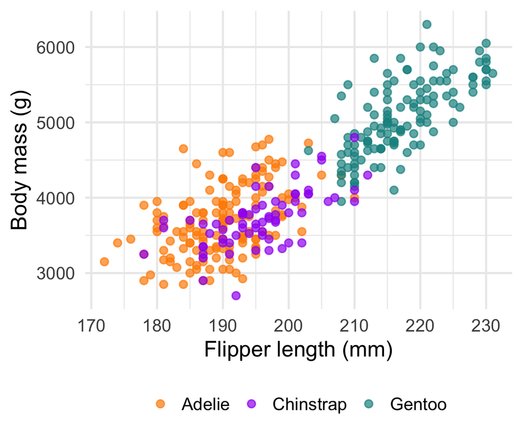

## How today works

We code.  
You code.

- Type along in **your own script**: don’t just watch
- Errors are normal. Read them out loud!
- Stuck? Put up a sticky note / raise your hand
- The **notes** have everything in detail, plus an exercise for each section

## The journey

Hello R → Variables → Data structures → Control flow

Packages → Functions → Reading data → Pipes

Tidy data → Summaries → Plots → Models & ML

The first half teaches you to *program*. The second half teaches you to *analyse data*.

# 01 Hello, R!

How do I tell a computer what to do?

## Console vs script

### Console

Like a **calculator**

Type a command, get an answer straight away. Gone when you close R.

### Script (`.R` file)

Like a **recipe**

Save your steps, re-run them any time, share them with others.

```
hello.R
```

```r
# Anything after a # is a comment: R ignores it
cat("Hello, penguins!")
```

## Your two best friends

**Ctrl/Cmd + Enter** Run the current line (or selection)

**`# comments`** Explain *why*, for future you

## Your turn ✍️

**Exercise 1** in the notes

Write `hello_penguins.R`: a comment, a variable holding a species name, and a greeting printed with `cat()`.

Answers are in the notes. Try it yourself first!

# 02 Variables & types

How do I make R remember things?

## A variable is a labelled box

```r
body_mass_g <- 3750
```

body_mass_g ← 3750

Read `<-` as **“gets”**: *body_mass_g gets 3750*

```r
body_mass_g / 1000
```

```
[1] 3.75
```

## Four types you’ll meet every day

**numeric** `39.1`

**integer** `181L`

**character** `"Adelie"`

**logical** `TRUE` / `FALSE`

```r
class("Adelie") # what type is this?
as.numeric("3750") # convert between types
```

## Asking questions

```r
species <- "Gentoo"
body_mass_g <- 5200

species == "Gentoo" & body_mass_g > 5000
```

```
[1] TRUE
```

**Maths** `+ - * / ^`

**Compare** `== != > < >= <=`

**Combine** `&` and, `|` or, `!` not

## Spot the mistake

`species = "Gentoo"` ← this **assigns**

`species == "Gentoo"` ← this **asks** “is it equal?”

`"3750" + 1` ← text, not a number: **error!**

## Your turn ✍️

**Exercise 2** in the notes

Describe a Gentoo penguin with variables, check their types, calculate its bill length:depth ratio, and test whether it’s a Gentoo **and** heavier than 5 kg.

Answers are in the notes. Try it yourself first!

# 03 Data structures

How do I store more than one thing?

## Four ways to hold data

**vector** One row of the **same** type  
`c(3750, 3800, 3250)`

**matrix** A grid of the **same** type  
`matrix(1:6, nrow = 2)`

**list** A bag of **anything**  
`list(species = "Adelie", mass = 3750)`

**data frame** A **table**: columns can differ  
`data.frame(species, mass)`

The **data frame** is the star of the show for the rest of the day ⭐

## Square brackets get things out

```r
masses <- c(3750, 3800, 3250, 3450)
masses[2]
```

```
[1] 3800
```

```r
masses[2:3]
```

```
[1] 3800 3250
```

```r
df <- data.frame(species = c("Adelie", "Gentoo"), mass = c(3750, 5200))
df[2, ] # row 2, all columns
```

```
  species mass
2  Gentoo 5200
```

```r
df$mass # one column
```

```
[1] 3750 5200
```

Counting starts at **1** in R. `[row, column]`, and leave a side blank to get everything.

## Errors are your friend

```r
df[, "flipper"]
```

```
Error in `[.data.frame`(df, , "flipper"): undefined columns selected
```

Where it happened : What went wrong

Read the error. It’s usually telling you exactly what’s wrong.

## Your turn ✍️

**Exercise 3** in the notes

Build a data frame of four penguins, add a `flipper_length_cm` column, and pull out the first three rows.

Answers are in the notes. Try it yourself first!

# 04 Control flow

How do I make decisions and repeat myself?

## `if`: making decisions

```r
if (mass > 4500) {
  cat("Large")
} else if (mass > 3500) {
  cat("Medium")
} else {
  cat("Small")
}
```

R runs the **first** match, then stops looking.  
**Most specific condition first!**

## Quick quiz 🤔

```r
mass <- 5000
if (mass > 3500) {
  cat("Medium")
} else if (mass > 4500) {
  cat("Large")
}
```

What gets printed?

“Medium” 😬

## `for`: do it for each one

Repetitive

```r
cat(masses[1] / 1000)
cat(masses[2] / 1000)
cat(masses[3] / 1000)
cat(masses[4] / 1000)
```

Loop

```r
for (mass in masses) {
  cat(mass / 1000, "kg\n")
}
```

Works for 4 penguins or 4 million.

## `while`: keep going until…

```r
fish <- 10
fed <- 0
while (fish >= 3) {
  fish <- fish - 3
  fed <- fed + 1
}
cat("Fed", fed, "penguins")
```

```
Fed 3 penguins
```

Make sure the condition can become `FALSE`, or it runs forever! (Press **Esc** to stop it.)

## Your turn ✍️

**Exercise 4** in the notes

Write `classify.R`: loop over 10 body masses, label each one *very large / large / medium / small*, and count the large ones.

Answers are in the notes. Try it yourself first!

# 05 Packages

How do I use code that other people have written?

## Packages are like apps

### 📥 Install: **once**

```r
install.packages("palmerpenguins")
```

Like downloading an app

### 📂 Load: **every session**

```r
library(palmerpenguins)
```

Like opening the app

Thousands of free packages on **CRAN**. Find them at rseek.org.

## Say hello to the data

```r
penguins
```

```
# A tibble: 344 × 8
   species island    bill_length_mm bill_depth_mm flipper_length_mm body_mass_g
   <fct>   <fct>              <dbl>         <dbl>             <int>       <int>
 1 Adelie  Torgersen           39.1          18.7               181        3750
 2 Adelie  Torgersen           39.5          17.4               186        3800
 3 Adelie  Torgersen           40.3          18                 195        3250
 4 Adelie  Torgersen           NA            NA                  NA          NA
 5 Adelie  Torgersen           36.7          19.3               193        3450
 6 Adelie  Torgersen           39.3          20.6               190        3650
 7 Adelie  Torgersen           38.9          17.8               181        3625
 8 Adelie  Torgersen           39.2          19.6               195        4675
 9 Adelie  Torgersen           34.1          18.1               193        3475
10 Adelie  Torgersen           42            20.2               190        4250
# ℹ 334 more rows
# ℹ 2 more variables: sex <fct>, year <int>
```

## The `tidyverse`

A family of packages that work together for data science

```r
library(tidyverse)
```

**readr** read files

**dplyr** manipulate

**tidyr** tidy up

**ggplot2** plot

**stringr** text

**forcats** categories

## Your turn ✍️

**Exercise 5** in the notes

Explore `?penguins` and `summary(penguins)`. How many penguins have a missing sex?

Answers are in the notes. Try it yourself first!

# 06 Functions

How do I write code I can reuse?

## A function is a machine

inputs (arguments) → function → output (return value)

```r
mean(c(3750, 3800, 3250))
```

```
[1] 3600
```

You’ve been using functions all along: `cat()`, `c()`, `class()`, `mean()`…

## Building your own

```r
calculate_mean <- function(values) {
  total <- 0
  count <- 0
  for (value in values) {
    total <- total + value
    count <- count + 1
  }
  return(total / count)
}
```

name ← function(arguments) → { body } → return()

## When things go wrong

### 🛑 `stop()`

Halt with a clear error

```r
if (!is.numeric(value)) {
  stop("I need numbers!")
}
```

### ⚠️ `warning()`

Carry on, but tell the user

```r
if (is.na(value)) {
  warning("Skipping an NA")
}
```

`NA` means “missing value”. Many functions skip them with `na.rm = TRUE`.

## Your turn ✍️

**Exercise 6** in the notes

Write `calculate_max()`. Make it **warn** on missing values and **stop** if there’s nothing left.

Answers are in the notes. Try it yourself first!

# 07 Reading data

How do I get my data into R?

## From file to table

```r
penguins_file <- path_to_file("penguins.csv") # a CSV that ships with the package

read.csv(penguins_file) # base R  → data.frame
read_csv(penguins_file) # readr   → tibble ✨
```

Packages can ship **files** as well as functions!

## Real data is messy

```
Palmer penguins data
Exported for the JGI R course.
A -1 signifies a missing value.

species;island;bill_length_mm;bill_depth_mm;...
Adelie;Torgersen;39.1;18.7;181;3750;male;2007
Adelie;Torgersen;-1;-1;-1;-1;-1;2007
```

Three problems: 📝 header text, ➗ semicolons, ❓ `-1` = missing

## Fix it one step at a time

```r
read_delim(
  messy_file,
  skip = 4, # 📝 skip the header text
  delim = ";", # ➗ split on semicolons
  na = "-1", # ❓ -1 means missing
  col_types = cols(year = col_integer())
) # set column types
```

## Your turn ✍️

**Exercise 7** in the notes

Read `penguins_raw.csv` and find the mean `Culmen Length (mm)`. (Watch out for those column names!)

Answers are in the notes. Try it yourself first!

# 08 Tibbles & the pipe

How do I ask questions of my data?

## The pipe `%>%` means “and then”

Take the penguins, **and then** keep the female Adelies, **and then** add mass in kg, **and then** sort.

```r
penguins %>%
  filter(species == "Adelie", sex == "female") %>%
  mutate(body_mass_kg = body_mass_g / 1000) %>%
  arrange(desc(body_mass_kg))
```

Shortcut: **Ctrl/Cmd + Shift + M**. You may also see R’s built-in pipe `|>`, which works the same way.

## Five verbs to rule them all

**`filter()`** keep **rows**

**`select()`** keep **columns**

**`mutate()`** make **new columns**

**`arrange()`** **sort** rows

**`rename()`** `new = old`

```r
penguins %>% select(species, island, body_mass_g)
```

## Your turn ✍️

**Exercise 8** in the notes

How many Chinstraps have flippers ≥ 200 mm? Which 5 penguins have the longest bills?

Answers are in the notes. Try it yourself first!

# 09 Tidy data

What shape should my data be?

## Three rules of tidy data

**1. Columns** Each variable has its own column

**2. Rows** Each observation has its own row

**3. Cells** Each value has its own cell

Tidy data in → easy analysis and plotting out

## Reshaping with `pivot_longer()`

| id | bill_length | bill_depth |
| --- | --- | --- |
| 1 | 39.1 | 18.7 |
| 2 | 39.5 | 17.4 |

→

| id | measurement | mm |
| --- | --- | --- |
| 1 | bill_length | 39.1 |
| 1 | bill_depth | 18.7 |
| 2 | bill_length | 39.5 |
| 2 | bill_depth | 17.4 |

```r
penguins %>%
  pivot_longer(
    c(bill_length_mm, bill_depth_mm),
    names_to = "measurement",
    values_to = "mm"
  )
```

`pivot_wider()` goes back. `drop_na()` removes missing values. `factor()` sets category order.

## Your turn ✍️

**Exercise 9** in the notes

How many rows does `drop_na()` remove? Pivot the bill measurements longer. How many rows now?

Answers are in the notes. Try it yourself first!

# 10 Data analysis

Which penguins are heaviest?

## Group, then summarise

```r
penguins %>%
  group_by(species) %>%
  summarise(mean_mass = mean(body_mass_g, na.rm = TRUE), n = n())
```

```
# A tibble: 3 × 3
  species   mean_mass     n
  <fct>         <dbl> <int>
1 Adelie        3701.   152
2 Chinstrap     3733.    68
3 Gentoo        5076.   124
```

Gentoo penguins are over 1 kg heavier on average!

## Filter → group → summarise

filter() → group_by() → summarise()

```r
penguins %>%
  drop_na(sex) %>%
  group_by(species, sex) %>%
  summarise(mean_mass = mean(body_mass_g), .groups = "drop")
```

```
# A tibble: 6 × 3
  species   sex    mean_mass
  <fct>     <fct>      <dbl>
1 Adelie    female     3369.
2 Adelie    male       4043.
3 Chinstrap female     3527.
4 Chinstrap male       3939.
5 Gentoo    female     4680.
6 Gentoo    male       5485.
```

## Your turn ✍️

**Exercise 10** in the notes

For each species: mean, min and max flipper length. Which island has the heaviest Adelies?

Answers are in the notes. Try it yourself first!

# 11 Plotting

How do I see what’s going on?

## The grammar of graphics

data + aesthetics: aes(x, y, colour) + layers: geom_…()

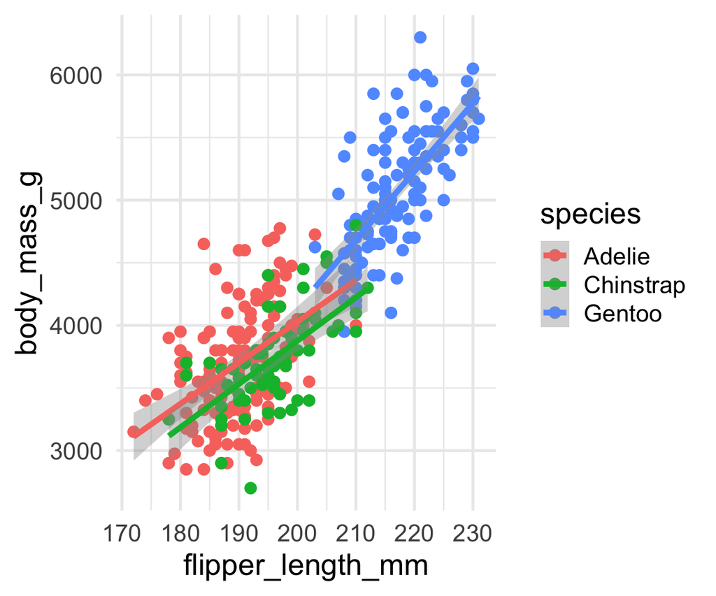

```r
ggplot(
  penguins,
  aes(x = flipper_length_mm, y = body_mass_g, colour = species)
) +
  geom_point() +
  geom_smooth(method = "lm")
```

## Pick the right geom

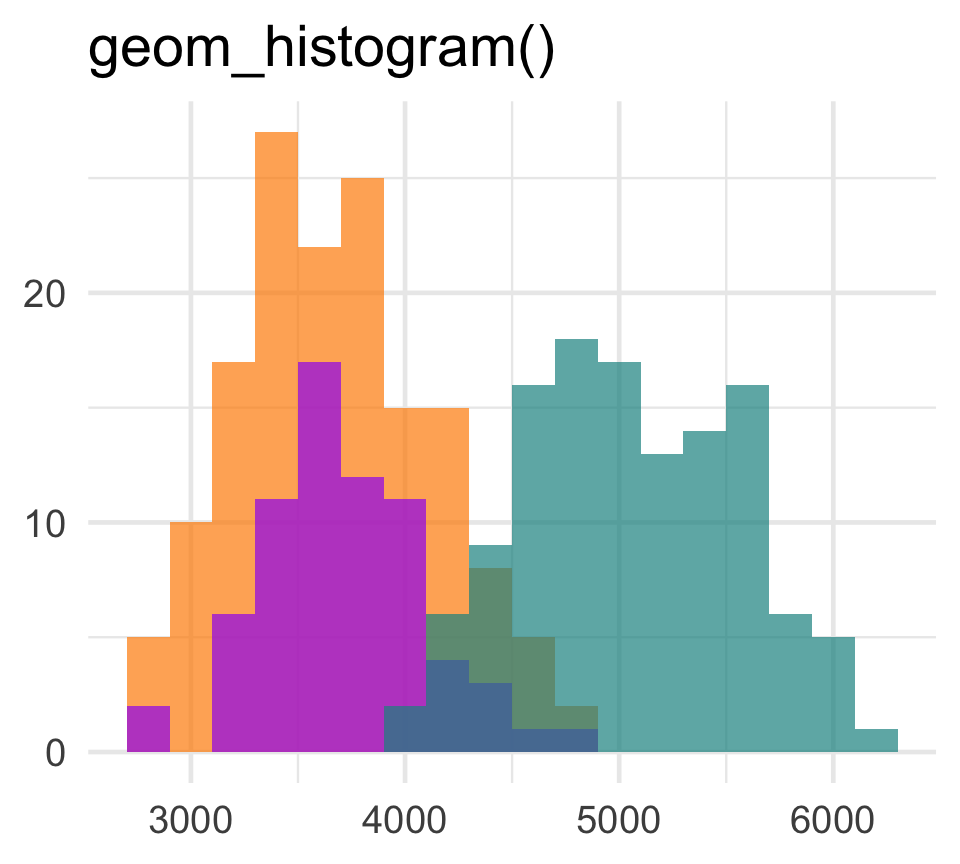

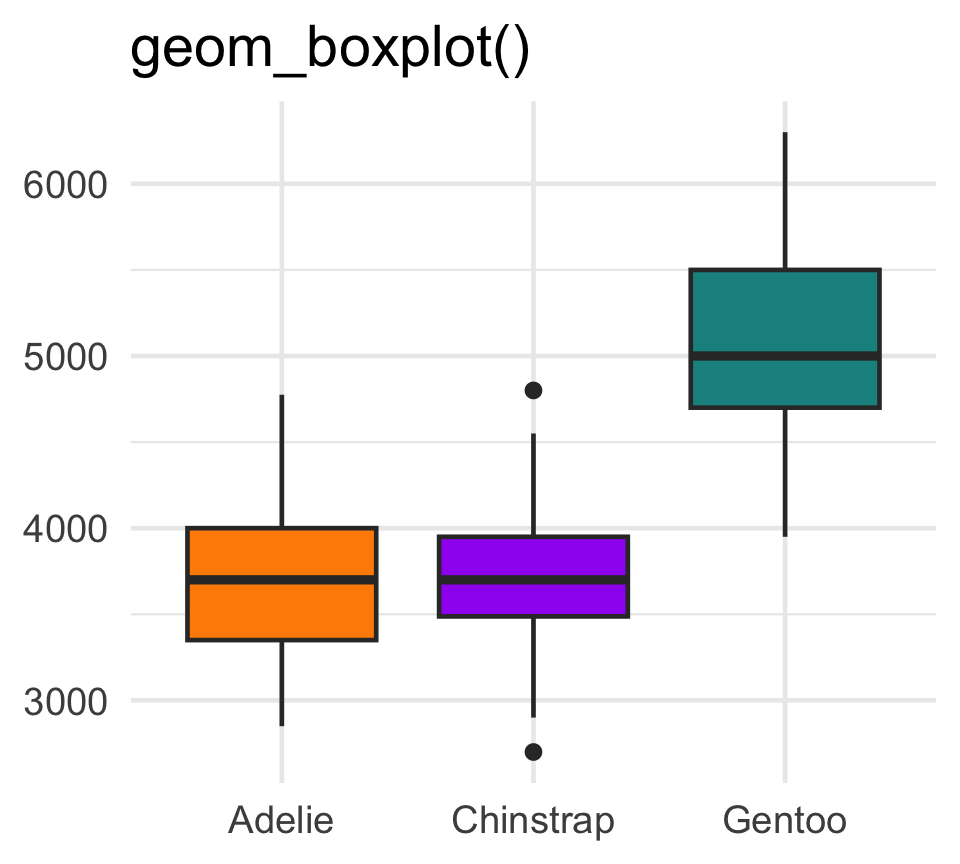

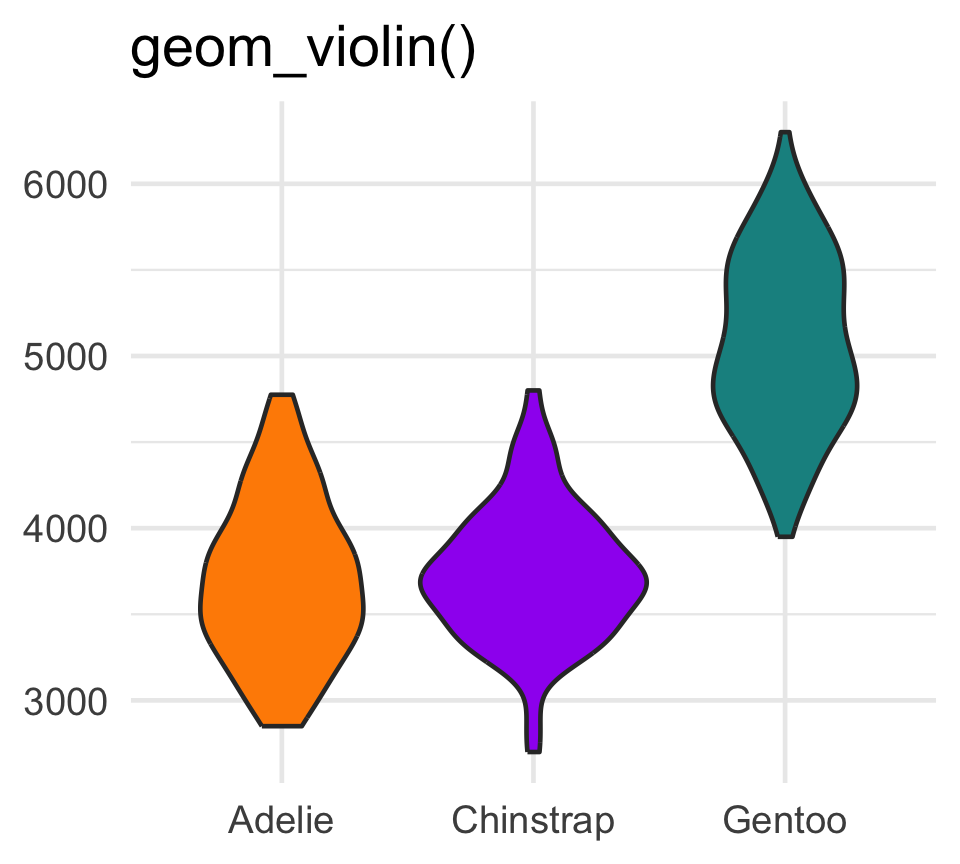

Same data, different questions. Swap the `geom`, keep everything else. Then `ggsave("plot.png")` to save it.

## Do longer bills mean deeper bills?

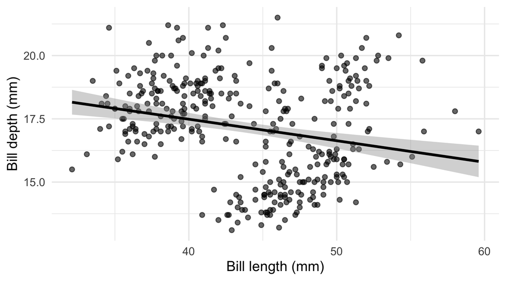

Looks like… **no**? Longer bills are *shallower*.

## Look again…

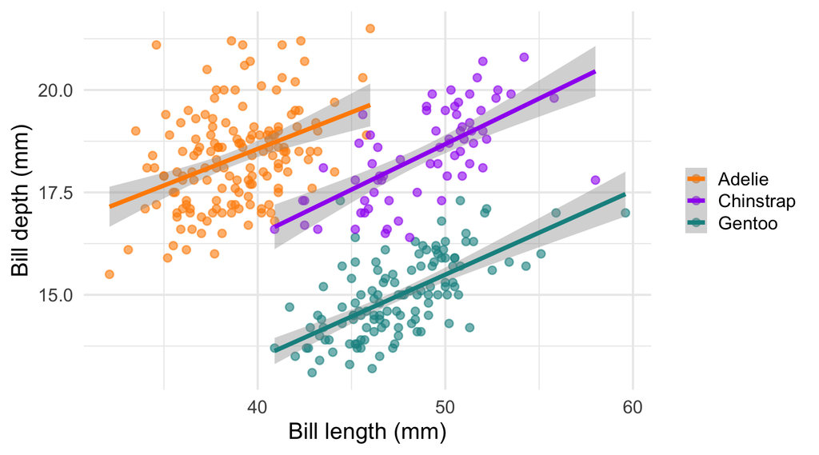

Within **every** species, longer bills are *deeper*. This is **Simpson’s paradox** 🤯

## Your turn ✍️

**Exercise 11** in the notes

Plot flipper length against bill length, coloured by species with a line for each. Then facet histograms of flipper length by species, add labels and a theme, and `ggsave()` it.

Answers are in the notes. Try it yourself first!

# 12 Models & machine learning

Can we predict a penguin’s weight, or even its species?

## From pictures to numbers

```r
model <- lm(body_mass_g ~ flipper_length_mm, data = penguins_complete)
coef(model)
```

```
      (Intercept) flipper_length_mm
      -5872.09268          50.15327
```

+1 mm of flipper ≈ +50 g of penguin

Formula: `outcome ~ predictors`. Then use `summary()`, `confint()`, `anova()`, `predict()`.

## The modelling toolbox

**`lm()`** A number outcome  
*“How heavy?”*

**`glm(family = binomial)`** A yes/no outcome  
*“Male or female?”*

**`lme4::lmer()`** Grouped data  
*`(1 | species)` gives each group its own baseline*

```r
lm(body_mass_g ~ flipper_length_mm + species + sex, data = penguins_complete)
```

Same formula style for all of them. Add predictors with `+`.

## Machine learning: two flavours

### 🔍 Unsupervised

*No answers given.* Find the groups yourself.

`prcomp()` · `kmeans()`

### 🎓 Supervised

*Learn from examples*, then predict new ones.

`rpart()` decision trees

## Can the computer find the species?

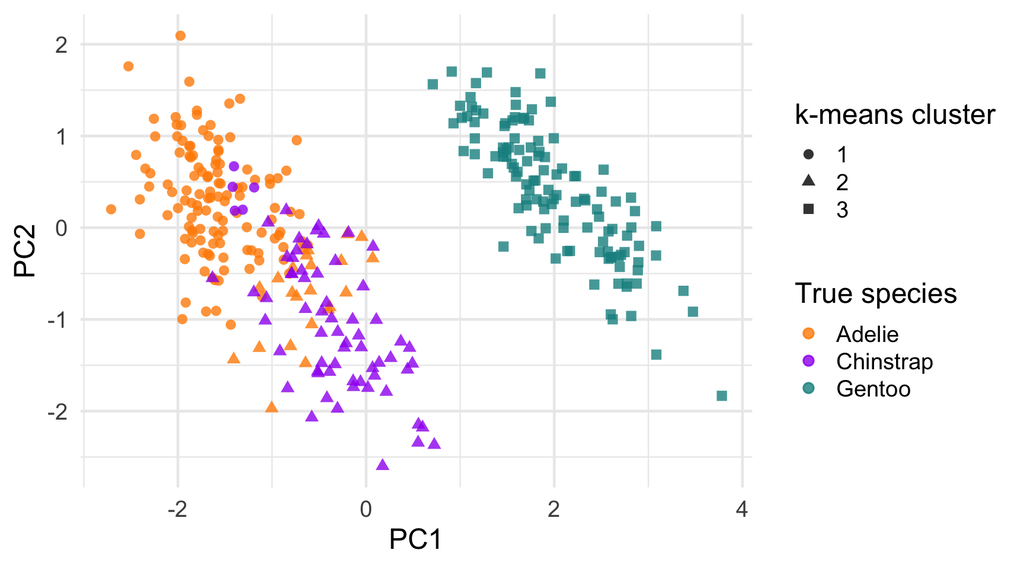

PCA squashes 4 measurements into 2 dimensions; k-means finds 3 clusters **without being told the species**.

## Teach a computer to identify penguins

```r
tree <- rpart(
  species ~ bill_length_mm +
    bill_depth_mm +
    flipper_length_mm,
  data = train
)

predict(tree, test, type = "class")
```

Train on 70%, test on the 30% it has **never seen**. Use `set.seed()` so results are reproducible.

Accuracy on unseen penguins:

94% 🎉

## Your turn ✍️

**Exercise 12** in the notes

Model bill depth against bill length with and without `species`: what happens to the slope? Then build a decision tree using bill measurements only.

Answers are in the notes. Try it yourself first!

# Wrapping up

## Look how far you’ve come

cat(“Hello, R!”) → variables & loops → functions → tidy data → plots → machine learning

You don’t need to remember it all.  
**Keep practising**, and keep the notes handy. They’re yours to keep.

## Where next?

**R for Data Science (2e)** [r4ds.hadley.nz](https://r4ds.hadley.nz/)

**ggplot2 book** ggplot2-book.org

**Cheat sheets** [posit.co/resources/cheatsheets](https://posit.co/resources/cheatsheets/)

**Statistical learning** [statlearning.com](https://www.statlearning.com/)

Thank you! Questions? 🐧